# wavelet analysis of pm2.5

wanzhen

2022-06-29

# 1 PM2.5

```r
library(WaveletComp)
library(imputeTS)
library(ggplot2)
library(tidyverse)
```

## 1.1 数据预处理，缺失值填补 impute

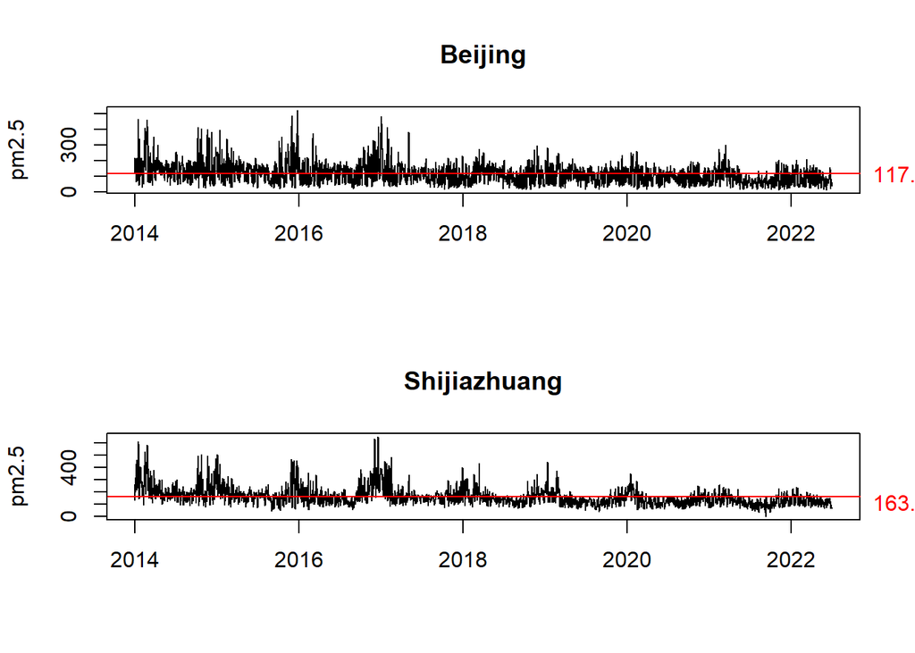

```r
pm2.5.sum <- data.frame(read.csv("sum_cityPm2.5.csv",header = TRUE))
ts.beijing <- ts(pm2.5.sum[,3],frequency = 365,start = c(2014,1))
avg.bj <- mean(ts.beijing,na.rm = TRUE)
ts.shijiazhuang <- ts(pm2.5.sum[,5],frequency = 365,start = c(2014,1))
avg.sjz <- mean(ts.shijiazhuang,na.rm = TRUE)
par(mfrow=c(2,1))
plot(ts.beijing,xlab="",ylab="pm2.5",main="Beijing")
abline(h=avg.bj,col="red")
mtext(text = round(avg.bj,1),side=4,at=avg.bj,las=1,line=0.5,col="red")
plot(ts.shijiazhuang,xlab="",ylab="pm2.5",main="Shijiazhuang")
abline(h=avg.sjz,col="red")
mtext(text = round(avg.sjz,1),side=4,at=avg.bj,las=2,line=0.5,col="red")
```

**从两地的时序图可知石家庄地区的pm2.5浓度水平明显高于北京地区的浓度水平,且两时间序列呈现一定的周期性，石家庄pm2.5浓度序列周期性更为明显，两地的pm2.5浓度在近六年有下降的趋势**

```r
#数据预处理，缺失值
obs.missing <- pm2.5.sum[(is.na(pm2.5.sum[,3]) | is.na(pm2.5.sum[,5])),c(2,3,5) ]
obs.missing
```

```
##            date 北京 石家庄
## 363  2014/12/29   NA     NA
## 364  2014/12/30   NA     NA
## 365  2014/12/31   NA     NA
## 731    2016/1/1   NA     NA
## 732    2016/1/2   NA     NA
## 733    2016/1/3  221     NA
## 1096 2016/12/31  379     NA
## 1097   2017/1/1  486     NA
## 1346   2017/9/7   NA     NA
## 1347   2017/9/8   NA     NA
## 1348   2017/9/9   NA     NA
## 1349  2017/9/10   NA     NA
## 1826 2018/12/31   NA     NA
## 2190 2019/12/30   NA     NA
## 2191 2019/12/31   NA     NA
## 2280  2020/3/29  122     NA
## 2281  2020/3/30  156     NA
```

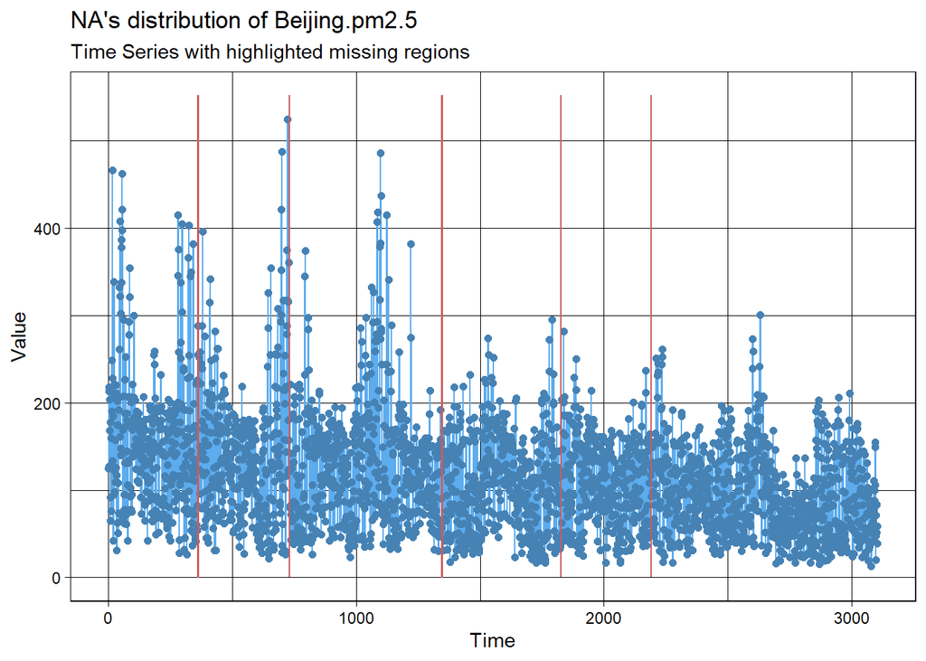

```r
#NA的分布
ggplot_na_distribution(ts.beijing,title = "NA's distribution of Beijing.pm2.5")
```

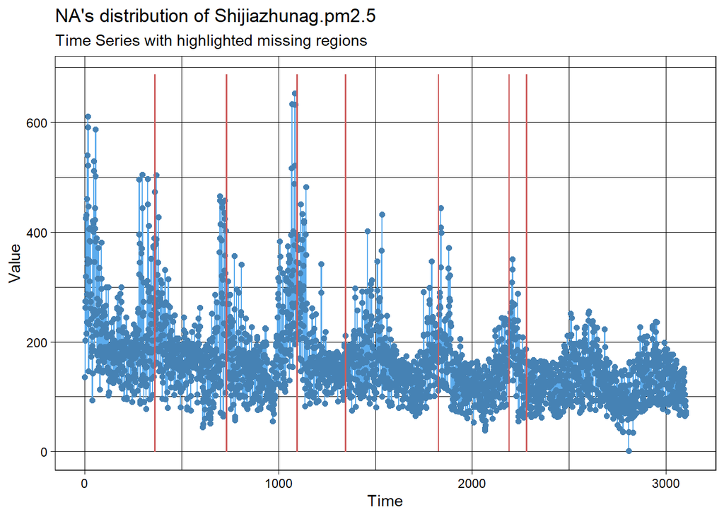

```r
ggplot_na_distribution(ts.shijiazhuang,title = "NA's distribution of Shijiazhunag.pm2.5")
```

```r
#缺失值线性插补
imp.beijing <- na_interpolation(ts.beijing, option="spline")
imp.shijiazhuang <- na_interpolation(ts.shijiazhuang,option = "spline")
com.bj <- data.frame(date=as.Date(pm2.5.sum$date),pm2.5=imp.beijing)
com.sjz <- data.frame(date=as.Date(pm2.5.sum$date),pm2.5=imp.shijiazhuang)
```

## 1.2 小波分析

### 1.2.1 北京pm2.5小波分析

```r
my.w <- analyze.wavelet(com.bj,"pm2.5",
                        dt=1,dj=1/100,
                        lowerPeriod = 16,
                        upperPeriod = 512,
                        make.pval = TRUE,n.sim = 10)
```

```
## Smoothing the time series...
## Starting wavelet transformation...
## ... and simulations...
##
## Class attributes are accessible through following names:
## series loess.span dt dj Wave Phase Ampl Power Power.avg Power.pval Power.avg.pval Ridge Period Scale nc nr coi.1 coi.2 axis.1 axis.2 date.format date.tz
```

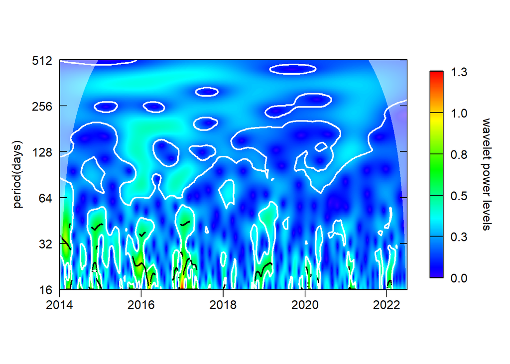

```r
#小波功率谱
wt.image(my.w,color.key="interval",n.levels = 250,
         periodlab = "period(days)",
         exponent = 0.4,
         legend.params = list(lab="wavelet power levels"),
         show.date = TRUE,date.format = "%F",timelab = "",
         timetcl = -0.5)
```

**选取周期为16-521的频段进行分析，在高频段时周期最为显著，但周期性在整个时间轴2014-2019上不连续,原因有待分析**

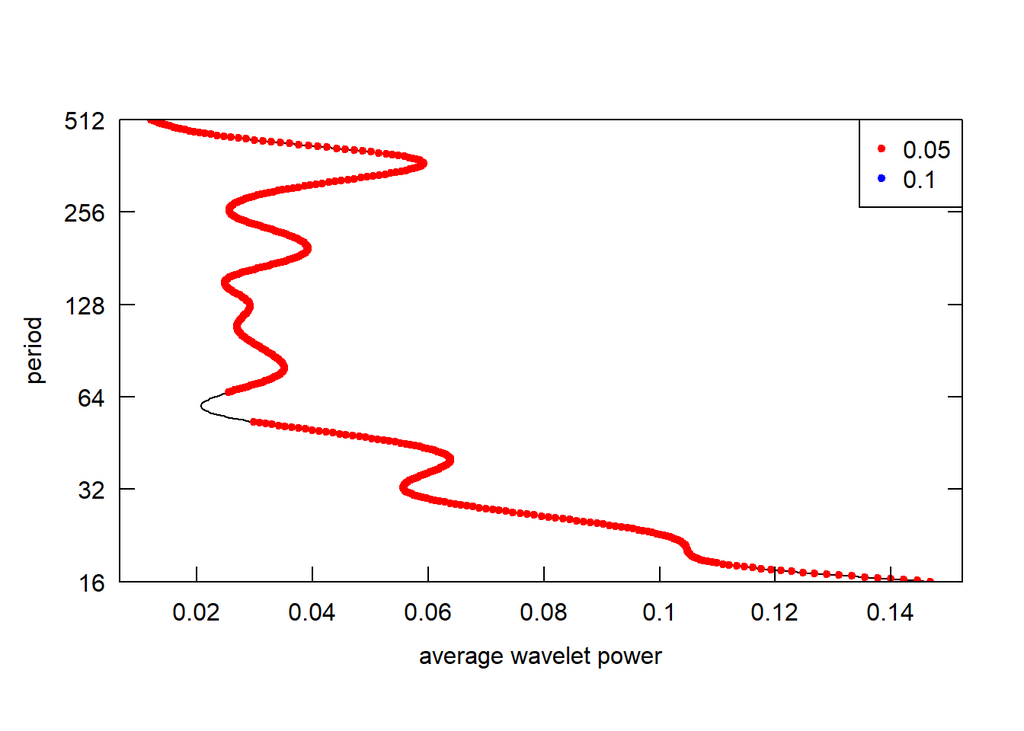

```r
#北京pm2.5时间序列的平均功率
maximum.level=1.001*max(my.w$Power.avg)
wt.avg(my.w,maximum.level = maximum.level)#北京pm2.5时间序列的平均功率
```

**小波分解的平均功率图中也证实高频段的幅度最大，其他频段的幅度相对较小**

### 1.2.2 石家庄pm2.5小波分析

```r
my.w.sjz <- analyze.wavelet(com.sjz,"pm2.5",
                        dt=1,dj=1/100,
                        lowerPeriod = 16,
                        upperPeriod = 512,
                        make.pval = TRUE,n.sim = 10)
```

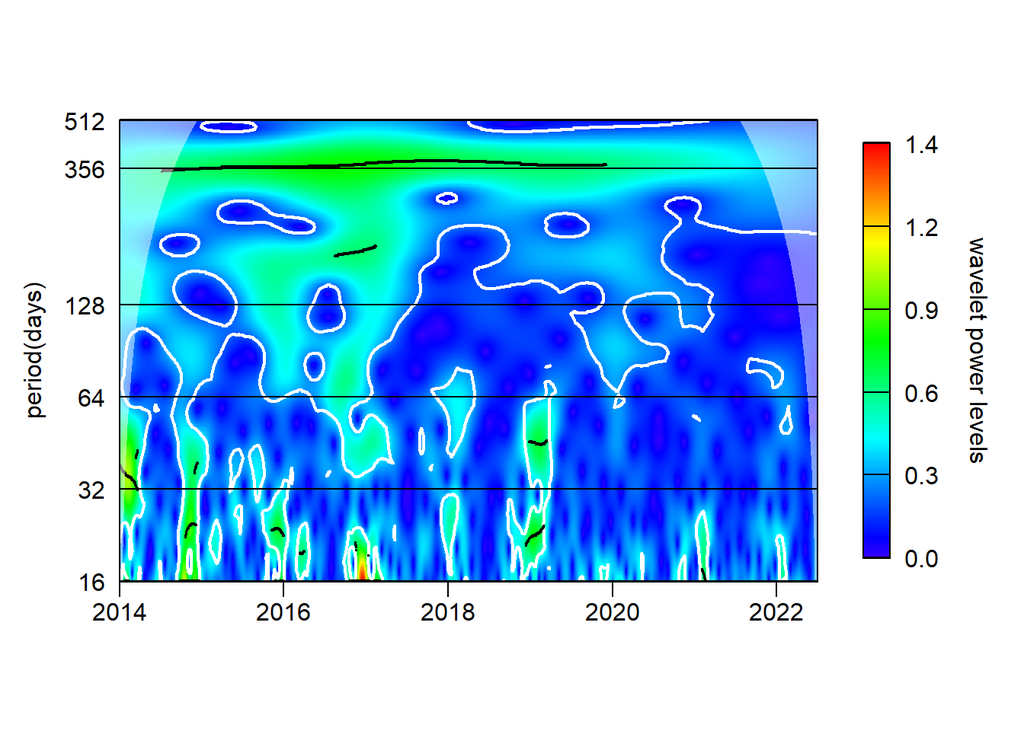

```r
wt.image(my.w.sjz,color.key = "interval",n.levels = 250,
         periodlab = "period(days)",
         exponent = 0.4,
         legend.params = list(lab="wavelet power levels"),
         show.date = TRUE,date.format="%F",timelab = "",
         timetcl = -0.5,
         spec.period.axis = list(at = c(16,32,64,128,356,512)),
         periodtck=1,periodtcl=NULL
         )
```

**石家庄的pm2.5时间序列小波频谱图可知，周期大约为356是显著的，并且在整个周期上显著性是连续**

## 1.3 北京和石家庄pm2.5小波相干分析

```r
my.data <- data.frame(date=as.Date(pm2.5.sum$date),pm2.5.bj=com.bj$pm2.5,pm2.5.sjz = com.sjz$pm2.5)
my.wc <- analyze.coherency(my.data,my.pair = c("pm2.5.bj","pm2.5.sjz"),
                           dt=1,dj=1/100,
                           window.type.t = 3,window.type.s = 3,
                           window.size.t = 5,window.size.s = 1,
                           lowerPeriod = 16,make.pval = TRUE,n.sim = 10)
```

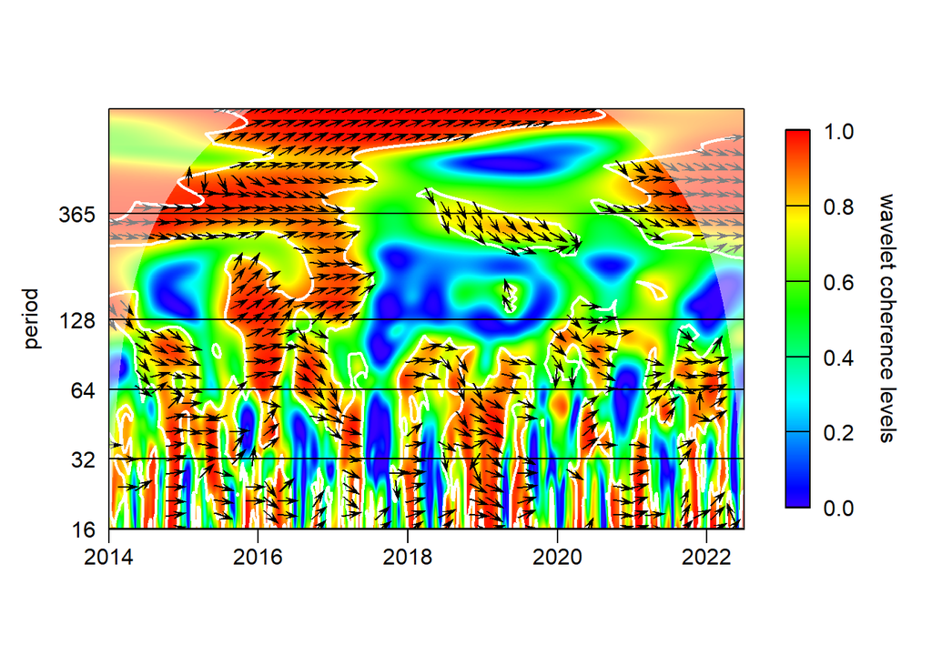

```r
#小波相干图
wc.image(my.wc,which.image = "wc",color.key = "interval",
         n.levels = 250,
         exponent = 1.5,
         timetcl = -0.5,
         siglvl.contour = 0.1,siglvl.arrow = 0.05,
         legend.params = list(lab="wavelet coherence levels"),
         timelab = "",
         show.date = TRUE,date.format = "%F",
         spec.period.axis = list(at=c(16,32,64,128,365)),
         periodtck = 1,
         periodtcl = NULL)
```

## 1.4 相位差分析

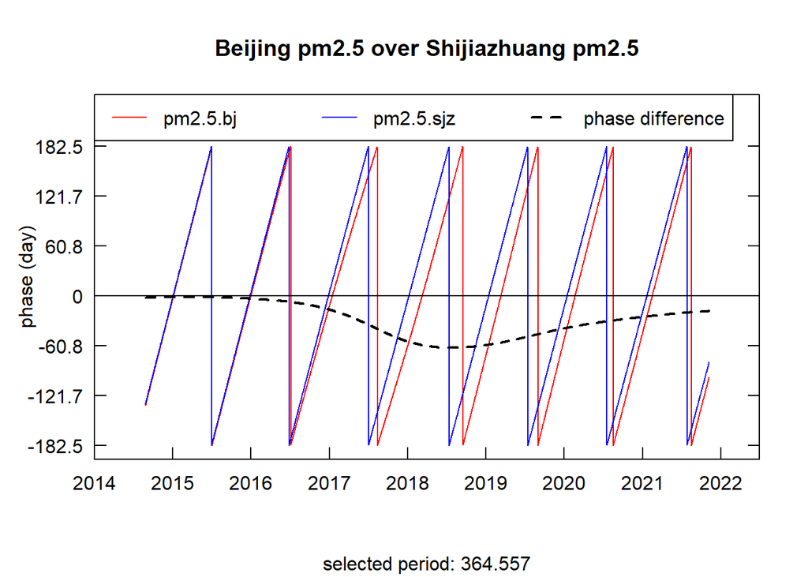

```r
at.ph <- seq(-pi,pi,by=pi/3)
labels.ph <- round(seq(-365/2,365/2,by=365/6),1)
at.t <- seq(from=as.Date("2014-01-01"),to=as.Date("2022-06-30"),by="years")
labels.t <- format(at.t,format="%Y")
wc.sel.phases(my.wc,sel.period=365,siglvl=1,
              spec.phase.axis = list(at=at.ph,labels=labels.ph),
              timelab = "",
              phaselab = "phase (day)",
              show.date = TRUE, date.format="%Y",
              spec.time.axis = list(at=at.t,labels=labels.t),
              only.coi = TRUE,
              main="Beijing pm2.5 over Shijiazhuang pm2.5")
abline(h=0)
```

**2014-2017北京和石家庄同时变化，2017-2022，北京和石家庄相位差为负，石家庄的pm2.5领先于北京，相位差先增后减，**

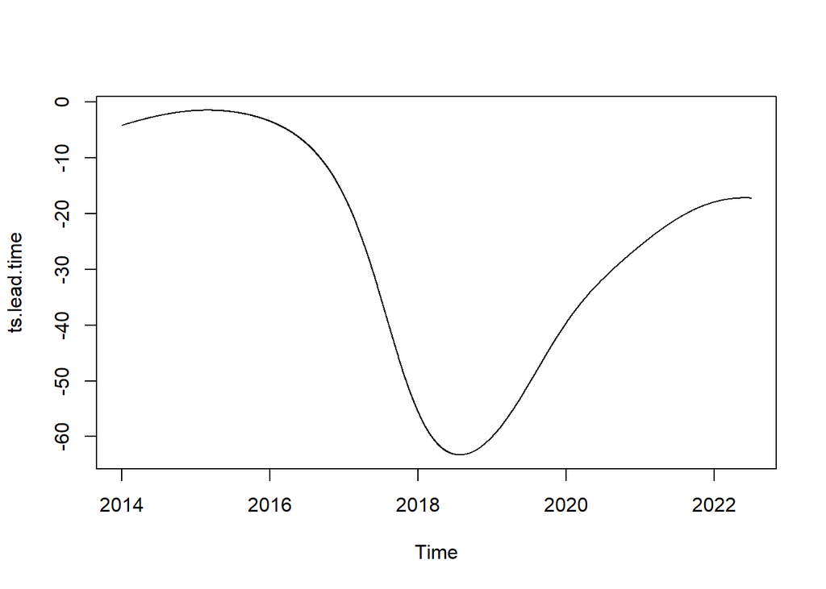

```r
row.closest.to.365 <- which.min(abs(my.wc$Period-365))
angle.series <- my.wc$Angle[row.closest.to.365,]
lead.time <- 365*(angle.series/(2*pi))
ts.lead.time<- ts(lead.time,frequency = 365,start = c(2014,1))
plot(ts.lead.time,color="red")
```